# Intro to the tidyverse

### geom_point

There are many different plot types (bar charts, scatter plots, histograms, etc). We tell our plot object what to draw by adding a “geometry” (“geom” for short) to our object. We will talk about many different geometries today, but for our first plot, let’s draw our data using the “points” geometry for each value in the data set. To do this, we add `geom_point()` to our plot object:

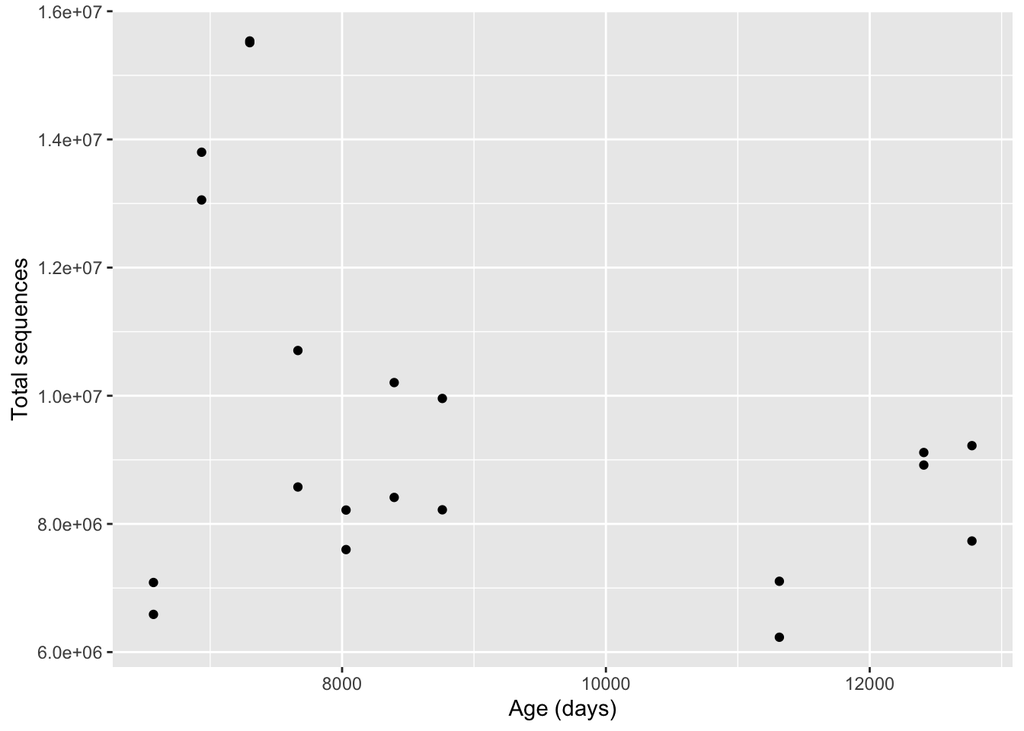

```r
meta %>%
ggplot() +
  aes(x = age_dys, y = total_seq) +
  labs(x = "Age (days)", y = "Total sequences") +
  geom_point()
```

Now we’re really getting somewhere. It finally looks like a proper plot! One thing we could do is use a different color for the sample conditions. To map the condition of each point to a color, we will again use the `aes()` function:

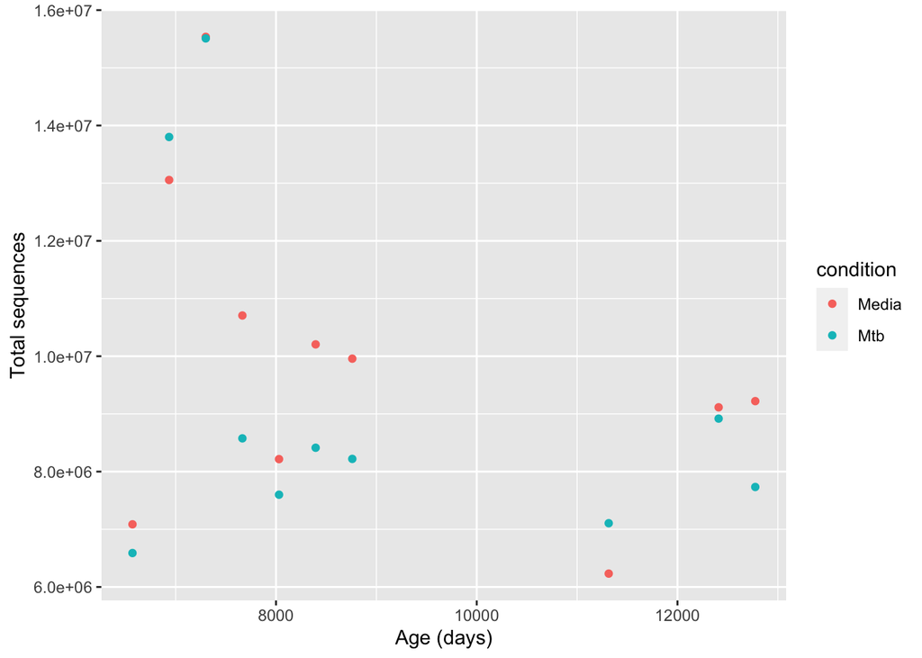

```r
meta %>%
ggplot() +
  aes(x = age_dys, y = total_seq, color = condition) +
  labs(x = "Age (days)", y = "Total sequences") +
  geom_point()
```

So far, we’ve been using `geom_point()` to plot two continuous (numeric) variables. What if we want to plot a categorical variable and a numeric variable?

### geom_boxplot

Using the `meta` data, use ggplot to create a box plot with condition on the x axis and total_seq on the y axis.

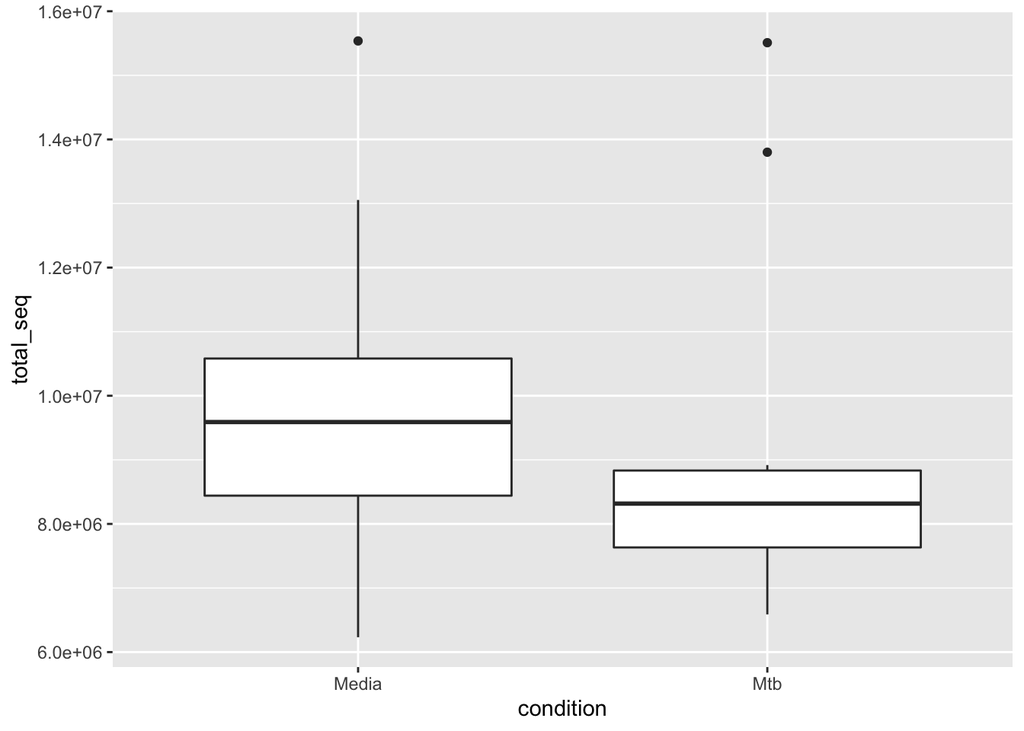

```r
meta %>%
 ggplot() +
  aes(x = condition, y = total_seq) +
  geom_boxplot()
```

This type of visualization makes it easy to compare the range and spread of values across groups. The “middle” 50% of the data is located inside the box and outliers that are far away from the central mass of the data are drawn as points.

### geom_col

Another way to plot a categorical and a continuous variable is with a bar plot.

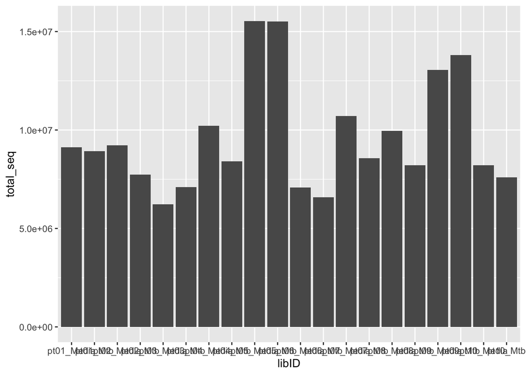

```r
meta %>%
  ggplot() +
  aes(x = libID, y = total_seq) +
  geom_col()
```

Those library IDs sure are squished together and hard to raed. Maybe we should have total_seq on the x axis and libID on the y axis. In other words, it might be easier if we flip the coordinates. We can rewrite the `aes()` code, or instead an easy way to change the coordinates is with `coord_flip()`:

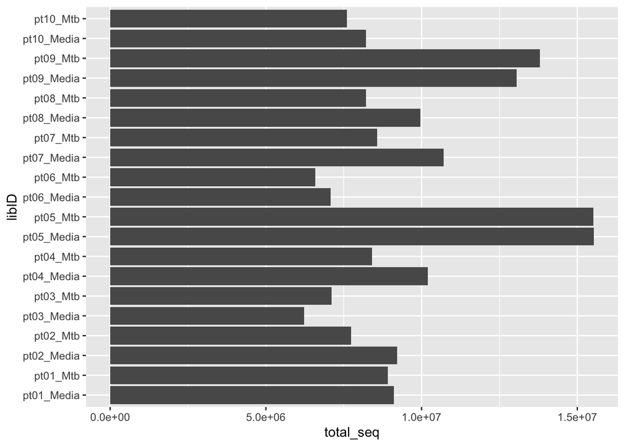

```r
meta %>%
  ggplot() +
  aes(x = libID, y = total_seq) +
  geom_col() +
  coord_flip()
```

This is looking pretty good. Now let’s add color using the `fill` aesthetic!

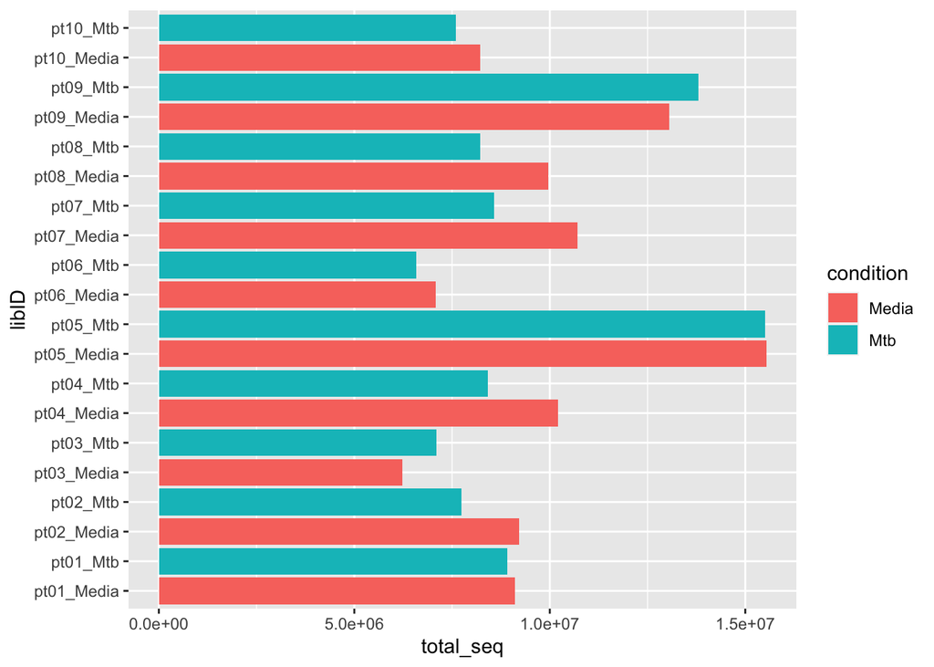

```r
meta %>%
  ggplot() +
  aes(x = libID, y = total_seq, fill = condition) +
  geom_col() +
  coord_flip()
```

Now let’s see if we can plot the total sequences for each patient ID:

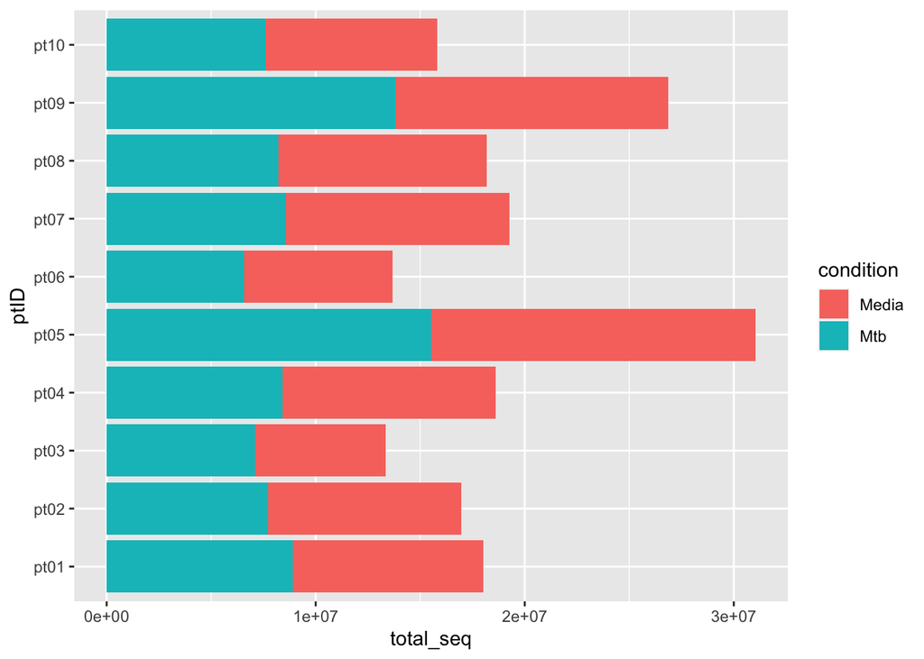

```r
meta %>%
  ggplot() +
  aes(x = ptID, y = total_seq, fill = condition) +
  geom_col() +
  coord_flip()
```

By default, the bars are stacked. Maybe we would like them to be side-by-side instead: We can tell the `geom_col` shapes to “dodge” each other:

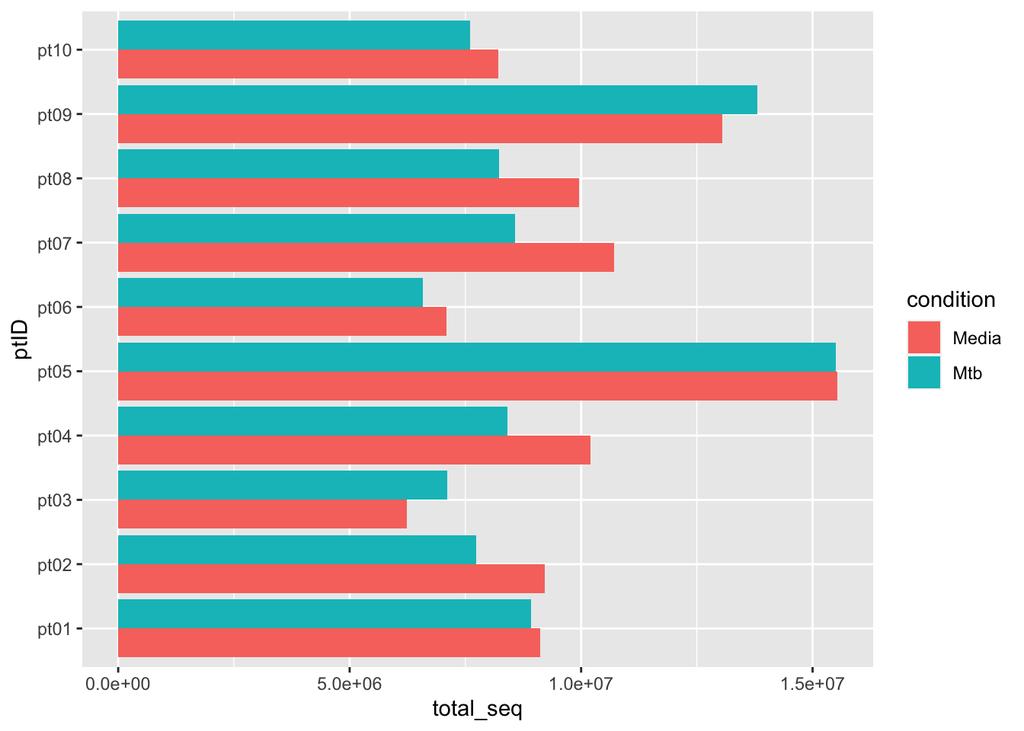

```r
meta %>%
  ggplot() +
  aes(x = ptID, y = total_seq, fill = condition) +
  geom_col(position = position_dodge()) +
  coord_flip()
```

Finally, since ptID is a short name, let’s flip our coordinates back by removing `coord_flip()`:

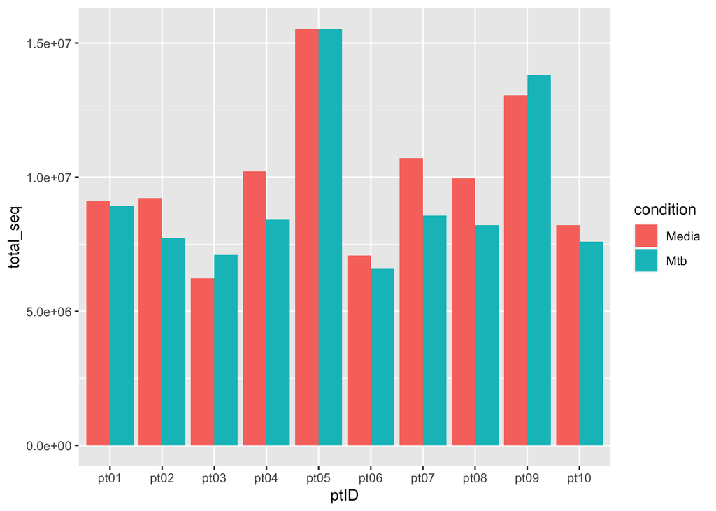

```r
meta %>%
  ggplot() +
  aes(x = ptID, y = total_seq, fill = condition) +
  geom_col(position = position_dodge())
```

We now have our first data cleaning plot, the total number of sequences per library.

### Saving plots

If we want to share our plots with other people or put them in manuscripts, we’re going to need to make them a little prettier and save them to our computers. Let’s make it pretty and then save the plot!

Add labels:

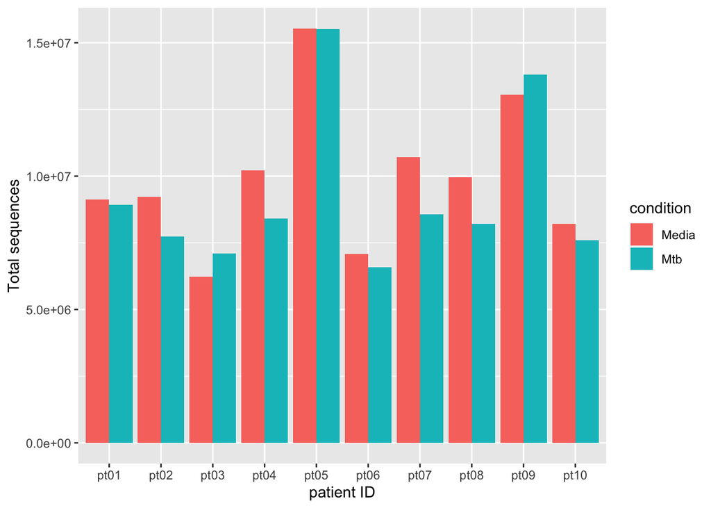

```r
meta %>%
  ggplot() +
  aes(x = ptID, y = total_seq, fill = condition) +
  geom_col(position = position_dodge()) +
  labs(x = 'patient ID', y = 'Total sequences')
```

Change the theme:

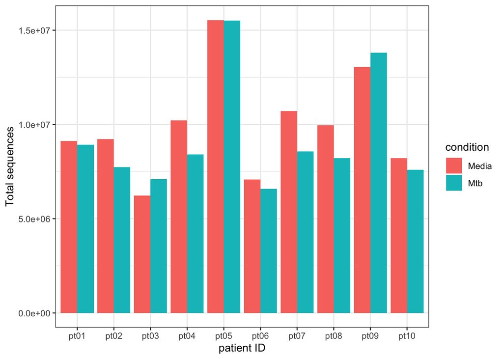

```r
meta %>%
  ggplot() +
  aes(x = ptID, y = total_seq, fill = condition) +
  geom_col(position = position_dodge()) +
  labs(x = 'patient ID', y = 'Total sequences') +
  theme_bw()
```

Save to a new variable:

```r
seq_per_lib_plot <- meta %>%
  ggplot() +
  aes(x = ptID, y = total_seq, fill = condition) +
  geom_col(position = position_dodge()) +
  labs(x = 'patient ID', y = 'Total sequences') +
  theme_bw()
```

Take a look at it by pasting the variable name into the console: `seq_per_lib_plot`

```r
ggsave("sequences_per_library.png", plot = seq_per_lib_plot)
```

## Intro tidyr

### pivot

Data comes in many shapes and sizes, and one way we classify data is either “wide” or “long.” Data that is “long” has one row per observation. The metadata is in a long format. We have one row for each patient sample and each variable is in a different column. We might describe this data as “tidy” because it makes it easy to work with `ggplot2` and `dplyr` functions (this is where the “tidy” in “tidyverse” comes from). As tidy as it may be, sometimes we may want our data in a “wide” format. Typically in “wide” format each row represents a group of observations and each value is placed in a different column rather than a different row. For example maybe we want only one row per country and want to spread the life expectancy values into different columns (one for each year).

The `tidyr` package contains the functions `pivot_wider` and `pivot_longer` that make it easy to switch between the two formats. The `tidyr` package is included in the `tidyverse` package so we don’t need to do anything to load it.

#### pivot_wider

For each patient, we have two samples: `Media` and `Mtb`. In the metadata, the only difference in these two conditions is the `libID` column (which is redundant with the `ptID` and `condition`) and the `total_seq` column. We can take the condition column and create two new columns, one with the total seqs in the media sample and one with the total seqs in the mtb sample. This is called “pivoting” the data frame “wider” because we rearrange it by creating an additional column and making it have fewer rows. Let’s try it!

```r
meta %>%
  select(-libID) %>%
  pivot_wider(names_from = condition, values_from = total_seq)
```

```
## # A tibble: 10 × 8
##    ptID  age_dys sex   RNAseq methylation age_yrs     Media       Mtb
##    <chr>   <dbl> <chr> <lgl>  <lgl>         <dbl>     <dbl>     <dbl>
##  1 pt01    12410 M     TRUE   FALSE          34.0  9114402.  8918699.
##  2 pt02    12775 M     TRUE   FALSE          35.0  9221555.  7733260.
##  3 pt03    11315 M     TRUE   FALSE          31.0  6231728.  7105193.
##  4 pt04     8395 M     TRUE   TRUE           23.0 10205557.  8413543.
##  5 pt05     7300 M     TRUE   FALSE          20.0 15536685. 15509446.
##  6 pt06     6570 F     TRUE   FALSE          18.0  7085995.  6588160.
##  7 pt07     7665 F     TRUE   FALSE          21.0 10706098.  8576245.
##  8 pt08     8760 M     TRUE   FALSE          24.0  9957906.  8220348.
##  9 pt09     6935 M     TRUE   FALSE          19.0 13055276  13800442.
## 10 pt10     8030 F     TRUE   FALSE          22.0  8216706.  7599609.
```

Maybe we should assign those columns more informative names:

```r
meta %>%
  select(-libID) %>%
  pivot_wider(names_from = condition, values_from = total_seq,
              names_prefix = "total_seq_")
```

```
## # A tibble: 10 × 8
##    ptID  age_dys sex   RNAseq methylation age_yrs total_seq_Media total_seq_Mtb
##    <chr>   <dbl> <chr> <lgl>  <lgl>         <dbl>           <dbl>         <dbl>
##  1 pt01    12410 M     TRUE   FALSE          34.0        9114402.      8918699.
##  2 pt02    12775 M     TRUE   FALSE          35.0        9221555.      7733260.
##  3 pt03    11315 M     TRUE   FALSE          31.0        6231728.      7105193.
##  4 pt04     8395 M     TRUE   TRUE           23.0       10205557.      8413543.
##  5 pt05     7300 M     TRUE   FALSE          20.0       15536685.     15509446.
##  6 pt06     6570 F     TRUE   FALSE          18.0        7085995.      6588160.
##  7 pt07     7665 F     TRUE   FALSE          21.0       10706098.      8576245.
##  8 pt08     8760 M     TRUE   FALSE          24.0        9957906.      8220348.
##  9 pt09     6935 M     TRUE   FALSE          19.0       13055276      13800442.
## 10 pt10     8030 F     TRUE   FALSE          22.0        8216706.      7599609.
```

And now let’s save the new wider metadata to a new variable:

```r
meta_wide <- meta %>%
  select(-libID) %>%
  pivot_wider(names_from = condition, values_from = total_seq)
```

Notice that the number of rows and columns has changed:

```r
nrow(meta)
```

```
## [1] 20
```

```r
ncol(meta)
```

```
## [1] 9
```

```r
nrow(meta_wide)
```

```
## [1] 10
```

```r
ncol(meta_wide)
```

```
## [1] 8
```

#### pivot_longer

Everything we did with `pivot_wider`, we can reverse with `pivot_longer`. Maybe you receive a data frame in a wide format, but you need it in a long format. Here’s how we can get back to a long data frame:

```r
meta_wide %>%
  pivot_longer(c(Media, Mtb),
               names_to = 'condition', values_to = 'total_seq')
```

```
## # A tibble: 20 × 8
##    ptID  age_dys sex   RNAseq methylation age_yrs condition total_seq
##    <chr>   <dbl> <chr> <lgl>  <lgl>         <dbl> <chr>         <dbl>
##  1 pt01    12410 M     TRUE   FALSE          34.0 Media      9114402.
##  2 pt01    12410 M     TRUE   FALSE          34.0 Mtb        8918699.
##  3 pt02    12775 M     TRUE   FALSE          35.0 Media      9221555.
##  4 pt02    12775 M     TRUE   FALSE          35.0 Mtb        7733260.
##  5 pt03    11315 M     TRUE   FALSE          31.0 Media      6231728.
##  6 pt03    11315 M     TRUE   FALSE          31.0 Mtb        7105193.
##  7 pt04     8395 M     TRUE   TRUE           23.0 Media     10205557.
##  8 pt04     8395 M     TRUE   TRUE           23.0 Mtb        8413543.
##  9 pt05     7300 M     TRUE   FALSE          20.0 Media     15536685.
## 10 pt05     7300 M     TRUE   FALSE          20.0 Mtb       15509446.
## 11 pt06     6570 F     TRUE   FALSE          18.0 Media      7085995.
## 12 pt06     6570 F     TRUE   FALSE          18.0 Mtb        6588160.
## 13 pt07     7665 F     TRUE   FALSE          21.0 Media     10706098.
## 14 pt07     7665 F     TRUE   FALSE          21.0 Mtb        8576245.
## 15 pt08     8760 M     TRUE   FALSE          24.0 Media      9957906.
## 16 pt08     8760 M     TRUE   FALSE          24.0 Mtb        8220348.
## 17 pt09     6935 M     TRUE   FALSE          19.0 Media     13055276
## 18 pt09     6935 M     TRUE   FALSE          19.0 Mtb       13800442.
## 19 pt10     8030 F     TRUE   FALSE          22.0 Media      8216706.
## 20 pt10     8030 F     TRUE   FALSE          22.0 Mtb        7599609.
```

##### sequence data

So far, we’ve been working with just the metadata. But this workshop is about analyzing RNAseq data, so let’s start working with actual sequencing data.

```r
count <- read_csv('0_data/raw_counts.csv')
```

Take a look at the counts data with: `View(count)`

Notice how each column is a `libID` and each row is a `hgnc_symbol`. The values are the raw sequence counts for the genes in each library. Soon, we’re going to want to combine the sequence data with our metadata. But first, we need to change this from a wide to a long format.

```r
count %>%
  pivot_longer(-hgnc_symbol, names_to = 'libID', values_to = 'raw_count')
```

```
## # A tibble: 895,720 × 3
##    hgnc_symbol libID      raw_count
##    <chr>       <chr>          <dbl>
##  1 5_8S_rRNA   pt01_Media     20.0
##  2 5_8S_rRNA   pt01_Mtb       20.0
##  3 5_8S_rRNA   pt02_Media      7.11
##  4 5_8S_rRNA   pt02_Mtb        6.06
##  5 5_8S_rRNA   pt03_Media     12.2
##  6 5_8S_rRNA   pt03_Mtb        4.07
##  7 5_8S_rRNA   pt04_Media      4
##  8 5_8S_rRNA   pt04_Mtb        3
##  9 5_8S_rRNA   pt05_Media     22.0
## 10 5_8S_rRNA   pt05_Mtb       55.7
## # … with 895,710 more rows
```

Let’s save this to a new data frame so we can re-use it later.

```r
count_long <- count %>%
  pivot_longer(-hgnc_symbol, names_to = 'libID', values_to = 'raw_count')
```

### join

Now let’s combine our raw sequence counts with our metadata. To combine two data frames, we will use a `join` function. The dplyr package has a number of tools for joining data frames together depending on what we want to do with the rows of the data of countries that are not represented in both data frames.

`?join`

We have a few options here:

> The mutating joins add columns from y to x, matching rows based on the keys: - inner_join(): includes all rows in x and y. - left_join(): includes all rows in x. - right_join(): includes all rows in y. - full_join(): includes all rows in x or y.

In an “inner join”, the new data frame only has those rows where the same key is found in both data frames. This is a very commonly used join.

```r
inner_join(meta, count_long, by = 'libID')
```

```
## # A tibble: 895,720 × 11
##    libID      ptID  condition age_dys sex   RNAseq methylation total_seq age_yrs
##    <chr>      <chr> <chr>       <dbl> <chr> <lgl>  <lgl>           <dbl>   <dbl>
##  1 pt01_Media pt01  Media       12410 M     TRUE   FALSE        9114402.    34.0
##  2 pt01_Media pt01  Media       12410 M     TRUE   FALSE        9114402.    34.0
##  3 pt01_Media pt01  Media       12410 M     TRUE   FALSE        9114402.    34.0
##  4 pt01_Media pt01  Media       12410 M     TRUE   FALSE        9114402.    34.0
##  5 pt01_Media pt01  Media       12410 M     TRUE   FALSE        9114402.    34.0
##  6 pt01_Media pt01  Media       12410 M     TRUE   FALSE        9114402.    34.0
##  7 pt01_Media pt01  Media       12410 M     TRUE   FALSE        9114402.    34.0
##  8 pt01_Media pt01  Media       12410 M     TRUE   FALSE        9114402.    34.0
##  9 pt01_Media pt01  Media       12410 M     TRUE   FALSE        9114402.    34.0
## 10 pt01_Media pt01  Media       12410 M     TRUE   FALSE        9114402.    34.0
## # … with 895,710 more rows, and 2 more variables: hgnc_symbol <chr>,
## #   raw_count <dbl>
```

Now let’s save our joined data frame to a new variable:

```r
full_data <- inner_join(meta, count_long, by = 'libID')
```

Now that we have our metadata joined with our raw count data, we’re ready to clean and analyze it!

#### Bonus: Other dplyr join functions

> Outer joins and can be performed using `left_join()`, `right_join()`, and `full_join()`. In a “left join”, if the key is present in the left hand data frame, it will appear in the output, even if it is not found in the the right hand data frame. For a right join, the opposite is true. For a full join, all possible keys are included in the output data frame.


## Using our joined dataset

Let’s find out which genes had the highest raw counts.

```r
top_10_abundant_genes <- full_data %>%
  filter(condition == 'Media') %>%
  group_by(hgnc_symbol) %>%
  summarize(med_raw_count = median(raw_count)) %>%
  arrange(desc(med_raw_count)) %>%
  slice_max(order_by = med_raw_count, n = 10)
top_10_abundant_genes
```

```
## # A tibble: 10 × 2
##    hgnc_symbol   med_raw_count
##    <chr>                 <dbl>
##  1 MALAT1              263231
##  2 Metazoa_SRP         208862.
##  3 RN7SL1              189057.
##  4 CH507-513H4.3       140705.
##  5 CH507-513H4.4       140705.
##  6 CH507-513H4.6       139025.
##  7 MT-RNR2             132437.
##  8 RN7SK                83060.
##  9 MT-RNR1              78763
## 10 MT-CO1               77922.
```

Now let’s make a boxplot with only those genes.

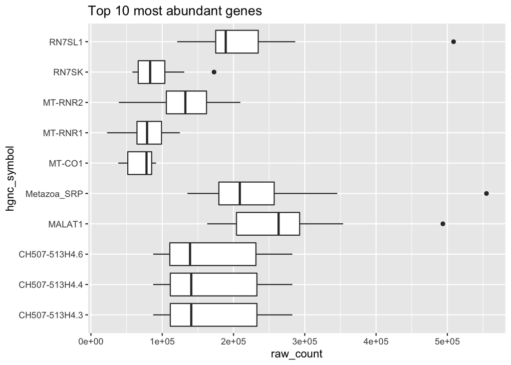

```r
full_data %>%
  filter(hgnc_symbol %in% top_10_abundant_genes$hgnc_symbol,
         condition == 'Media') %>%
  ggplot() +
  aes(x = hgnc_symbol, y = raw_count) +
  geom_boxplot() +
  coord_flip() +
  labs(title = 'Top 10 most abundant genes')
```

Try plotting just interferon 1 gamma for each patient:

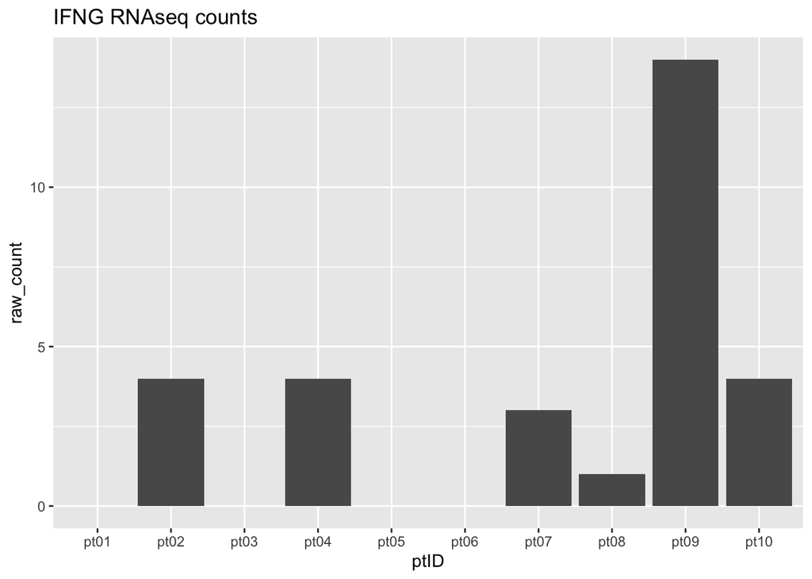

```r
full_data %>%
  filter(hgnc_symbol == 'IFNG', condition == 'Media') %>%
  ggplot() +
  aes(x = ptID, y = raw_count) +
  geom_col() +
  labs(title = 'IFNG RNAseq counts')
```

# *Navigation*

- [Workshop index](https://bigslu.github.io/2022_ASM_Microbe_RNAseq/index.html)
- Previous lesson: [Intro to R and RStudio](https://bigslu.github.io/2022_ASM_Microbe_RNAseq/1_introR/1_intro-R.html)
- Next lesson: [RNA-seq data cleaning](https://bigslu.github.io/2022_ASM_Microbe_RNAseq/3_RNAseq_cleaning/3_RNAseq_cleaning.html)
- [Lesson source code](https://github.com/BIGslu/2022_ASM_Microbe_RNAseq/tree/main/2_tidyverse/2_tidyverse.Rmd)